## Load data and packages

```r
library(tidyverse)

LA <- read_csv("LAHomes.csv")

glimpse(LA)
```

```
## Rows: 1,594
## Columns: 8
## $ city   <chr> "Long Beach", "Long Beach", "Long Beach", "Long Beach", "Long B~
## $ bed    <dbl> 0, 0, 0, 0, 0, 1, 1, 1, 1, 1, 1, 1, 1, 1, 1, 1, 1, 1, 1, 1, 1, ~
## $ bath   <dbl> 1, 1, 1, 1, 1, 1, 1, 1, 1, 1, 1, 1, 1, 1, 1, 1, 1, 1, 1, 1, 1, ~
## $ garage <chr> NA, NA, NA, "1", "1", NA, NA, NA, NA, NA, NA, NA, NA, "1", "1",~
## $ sqft   <dbl> 513, 550, 550, 1030, 1526, 552, 558, 596, 744, 750, 750, 791, 7~
## $ pool   <chr> NA, NA, NA, NA, NA, NA, NA, NA, NA, NA, NA, NA, NA, NA, NA, NA,~
## $ spa    <lgl> NA, NA, NA, NA, NA, NA, NA, NA, NA, NA, NA, NA, NA, NA, NA, NA,~
## $ price  <dbl> 119000, 153000, 205000, 300000, 375000, 159900, 135000, 105000,~
```

```r
summary(LA)
```

```
##      city                bed              bath           garage
##  Length:1594        Min.   : 0.000   Min.   : 1.000   Length:1594
##  Class :character   1st Qu.: 2.000   1st Qu.: 1.000   Class :character
##  Mode  :character   Median : 3.000   Median : 2.000   Mode  :character
##                     Mean   : 2.755   Mean   : 2.444
##                     3rd Qu.: 3.000   3rd Qu.: 3.000
##                     Max.   :17.000   Max.   :30.000
##       sqft           pool             spa              price
##  Min.   :  403   Length:1594        Mode:logical   Min.   :  100000
##  1st Qu.:  960   Class :character   NA's:1594      1st Qu.:  275000
##  Median : 1380   Mode  :character                  Median :  488944
##  Mean   : 1963                                     Mean   : 1254851
##  3rd Qu.: 2078                                     3rd Qu.:  988750
##  Max.   :28000                                     Max.   :89950000
```

## Cleaning

1. `spa`. All missing.

```r
table(LA$spa, useNA = "always")
```

```
##
## <NA>
## 1594
```

2. `pool`. Pool has 1448 NAs. NA probably means no pool? Hard to know for sure.

```r
table(LA$pool, useNA = "always")
```

```
##
##    Y <NA>
##  146 1448
```

3. `garage`. Garage has 625 NAs, which probably means no garage?

```r
table(LA$garage, useNA = "always")
```

```
##
##    1    2    3   4+ <NA>
##  260  666   37    6  625
```

Later we will learn how to impute NAs (meaning: replace the missing values with educated guesses); for now we will allow `lm()` to remove these observations. Let’s do some necessary recoding, given these (possibly imperfect) data modeling decisions:

1. Clearly we can just remove `spa`.
2. Recode NAs in `pool` as “N,” to be consistent with “Y.” Make it into a factor.
3. Recode empty garage as “0”—a character variable—and make it into a factor variable.
4. Make city into a factor.

To recode NAs we could use something like this: `ifelse(test = is.na(variable), yes = x, no = y).` However, we will use the `replace_na()` function in the tidyr package (loaded automatically with the tidyverse), which works well.

```r
LA_clean <- LA %>% # save the clean dataset in a separate object
 dplyr::select(-spa) %>%
  # remove spa
  mutate(pool = replace_na(pool, "N") %>% factor, # replace NAs in pool with "N"
        garage = replace_na(garage, "0") %>% factor, # Replace NAs in garage with "0"
        city = factor(city)) # Factor city.  Note that Beverly Hills is the reference level.


glimpse(LA_clean)
```

```
## Rows: 1,594
## Columns: 7
## $ city   <fct> Long Beach, Long Beach, Long Beach, Long Beach, Long Beach, Lon~
## $ bed    <dbl> 0, 0, 0, 0, 0, 1, 1, 1, 1, 1, 1, 1, 1, 1, 1, 1, 1, 1, 1, 1, 1, ~
## $ bath   <dbl> 1, 1, 1, 1, 1, 1, 1, 1, 1, 1, 1, 1, 1, 1, 1, 1, 1, 1, 1, 1, 1, ~
## $ garage <fct> 0, 0, 0, 1, 1, 0, 0, 0, 0, 0, 0, 0, 0, 1, 1, 1, 1, 1, 2, 2, 2, ~
## $ sqft   <dbl> 513, 550, 550, 1030, 1526, 552, 558, 596, 744, 750, 750, 791, 7~
## $ pool   <fct> N, N, N, N, N, N, N, N, N, N, N, N, N, N, N, N, N, N, N, N, N, ~
## $ price  <dbl> 119000, 153000, 205000, 300000, 375000, 159900, 135000, 105000,~
```

```r
summary(LA_clean)
```

```
##             city           bed              bath        garage
##  Beverly Hills: 232   Min.   : 0.000   Min.   : 1.000   0 :625
##  Long Beach   :1062   1st Qu.: 2.000   1st Qu.: 1.000   1 :260
##  Santa Monica : 204   Median : 3.000   Median : 2.000   2 :666
##  Westwood     :  96   Mean   : 2.755   Mean   : 2.444   3 : 37
##                       3rd Qu.: 3.000   3rd Qu.: 3.000   4+:  6
##                       Max.   :17.000   Max.   :30.000
##       sqft       pool         price
##  Min.   :  403   N:1448   Min.   :  100000
##  1st Qu.:  960   Y: 146   1st Qu.:  275000
##  Median : 1380            Median :  488944
##  Mean   : 1963            Mean   : 1254851
##  3rd Qu.: 2078            3rd Qu.:  988750
##  Max.   :28000            Max.   :89950000
```

## Questions

Lightly comment your code and use pipes for readability.

Comment briefly on each of the questions, as directed. Only the the final question requires a more lengthy response.

## Q1

Modeling price data often requires log transformation. Why? Log transformation compresses right skewed data and helps the linear model fit better. The function we often use in R for log transformation, `log(x)`, uses the natural log. (`log2(x)` will compute log base 2.) Let’s look at a plot of `sqft` and `price`:

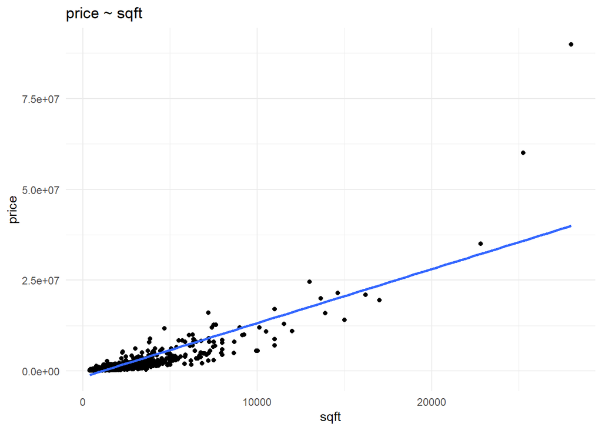

```r
ggplot(LA_clean, aes(sqft, price)) +
  geom_point() +
  theme_minimal() +
  stat_smooth(method="lm", se = F) +
  labs(title = "price ~ sqft")
```

The problem with price is that it spans many orders of magnitude. And the relationship between price and square feet is not linear, especially in Beverly Hills.

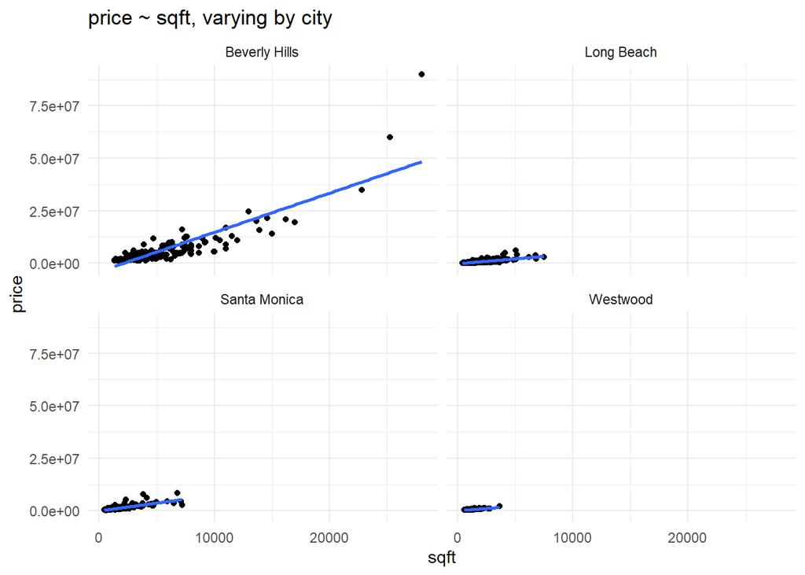

```r
ggplot(LA_clean, aes(sqft, price)) +
  geom_point() +
  theme_minimal() +
  facet_wrap(~city) +
  stat_smooth(method="lm", se = F) +
  labs(title = "price ~ sqft, varying by city")
```

After log transformation of price, each fixed distance in price represents a multiplication (not an addition) of the value.

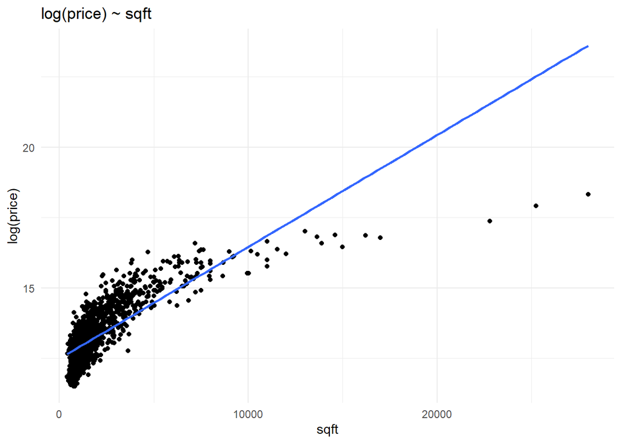

```r
ggplot(LA_clean, aes(sqft, log(price))) +
  geom_point() +
  theme_minimal() +
  stat_smooth(method="lm", se = F) +
  labs(title = "log(price) ~ sqft")
```

That doesn’t look like an improvement. Remember that our goal in transforming the data is to make the relationship between two variables linear, so as to improve the fit of a linear model. The problem is that `sqft` is also right skewed. So, let’s log transform `sqft` as well.

1. Create a plot of log `price` against log `sqft`, with a least squares summary line (called a log-log model).
2. Comment on this model’s fit to the data.

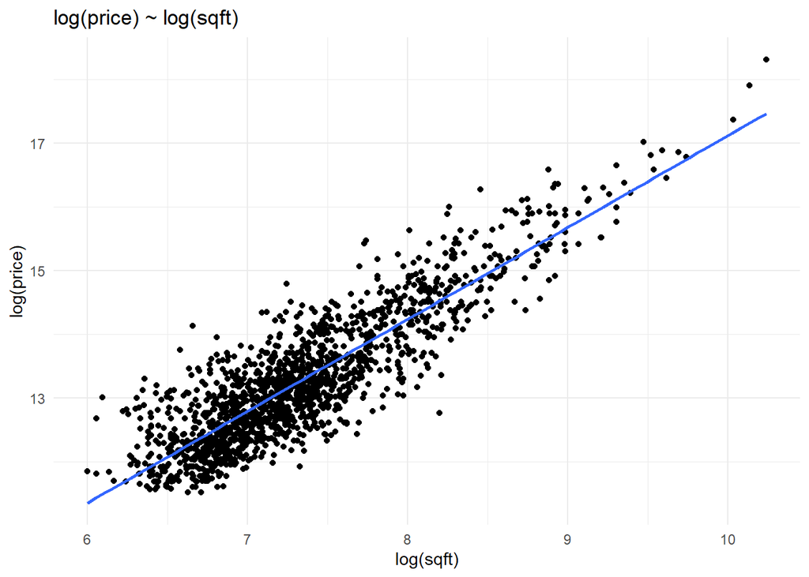

```r
ggplot(LA_clean, aes(log(sqft), log(price))) +
  geom_point() +
  theme_minimal() +
  stat_smooth(method="lm", se = F) +
  labs(title = "log(price) ~ log(sqft)")
```

> Comment on this model’s fit to the data: Adding the least squares summary lines helps increase the fit.

## Q2

Fit a log-log simple regression model: regress `log(price)` (the outcome) on `log(sqft)` (the predictor). Report and interpret the coefficient for `log(sqft)`.

```r
(loglog_model_pac <- lm(log(price) ~ log(sqft), data = LA_clean)) %>%
  summary
```

```
##
## Call:
## lm(formula = log(price) ~ log(sqft), data = LA_clean)
##
## Residuals:
##      Min       1Q   Median       3Q      Max
## -1.75640 -0.35315 -0.04846  0.32215  1.82580
##
## Coefficients:
##             Estimate Std. Error t value Pr(>|t|)
## (Intercept)  2.70279    0.14369   18.81   <2e-16 ***
## log(sqft)    1.44158    0.01954   73.79   <2e-16 ***
## ---
## Signif. codes:  0 '***' 0.001 '**' 0.01 '*' 0.05 '.' 0.1 ' ' 1
##
## Residual standard error: 0.496 on 1592 degrees of freedom
## Multiple R-squared:  0.7738, Adjusted R-squared:  0.7736
## F-statistic:  5446 on 1 and 1592 DF,  p-value: < 2.2e-16
```

```r
#use exponate to change from log price to real terms price.
```

# is the 1.44 a dollar increase for every 1 square foot increase?

> Report and interpret the coefficient: A 1 sqft log increase in a house is associated with a 1.44 unit log increase in price. Or a 1% increase in sqft = a 1.44% increase in price.

## Q3

We have been assuming, based on the plotting we did, that these log transformations have improved the model. Show, empirically, that they have. Fit two models:

1. price ~ sqft,
2. log(price) ~ log(sqft).  
   #what am I supposed to look at here? Do I create a new model or use the model from the previous question?

Calculate and report RMSE and R-squared for each model. Keep in mind when calculating RMSE that the prediction and the observed outcome have to be on the same scale; if you compare a logged prediction (from a model with a log transformed outcome) with an unlogged outcome variable you will get a crazy answer that is an artifact of the mismatch in scaling. So, you will need to exponentiate the logged prediction (from the log-log model) in order to return it to the original scale and make it comparable to the unlogged outcome. By “exponentiate” I mean: “raise e to the power of n,” where n is the natural log of price. Remember that exponentiation undoes log transformation, and vice versa. Use this identity: $e^{ln(x)}$ = x. In R this identity is `exp(log(x))` = x.

```r
#R Squared

model_pac <- lm(price ~ sqft, data = LA_clean)

summary(model_pac) $r.square
```

```
## [1] 0.7289673
```

```r
summary(loglog_model_pac) $r.square
```

```
## [1] 0.7737839
```

```r
#RMSE
rmse <- function(actual, fitted) sqrt(mean((actual - fitted)^2))

rmse(actual = LA_clean$price, fitted = predict(model_pac))
```

```
## [1] 1857904
```

```r
rmse(LA_clean$price, exp(fitted(loglog_model_pac)))
```

```
## [1] 1788187
```

> Report RMSE and R-squared for each model: 1. price ~ sqft: R squared = .72 RMSE = 1857904 2. log-log model R squared = .77 RMSE = 1788187

## Q4

Does the relationship between `price` and `sqft` in the log-log model vary by city? (This is equivalent to the question: is there and interaction between sqft and city?)

1. Fit a model of `log(price)` with an interaction between `log(sqft)` and `city`. To understand an interaction model it is helpful to create a plot.
2. Create a plot of the interaction between `city` and `sqft` with summary least squares lines. The clearest plot will be one in which all of the regression lines are on one plot.

```r
# Regression
#How to interpret the output?

(log_reg_model <- lm(log(price) ~ log(sqft) * city, data = LA_clean)) %>%
  summary #
```

```
##
## Call:
## lm(formula = log(price) ~ log(sqft) * city, data = LA_clean)
##
## Residuals:
##      Min       1Q   Median       3Q      Max
## -1.28790 -0.23915 -0.01744  0.21336  1.38916
##
## Coefficients:
##                            Estimate Std. Error t value Pr(>|t|)
## (Intercept)                 5.00555    0.33231  15.063  < 2e-16 ***
## log(sqft)                   1.20673    0.04002  30.157  < 2e-16 ***
## cityLong Beach             -0.72166    0.37512  -1.924 0.054557 .
## citySanta Monica            1.52351    0.46472   3.278 0.001067 **
## cityWestwood                2.20307    0.90552   2.433 0.015087 *
## log(sqft):cityLong Beach   -0.01514    0.04684  -0.323 0.746529
## log(sqft):citySanta Monica -0.21448    0.05985  -3.584 0.000349 ***
## log(sqft):cityWestwood     -0.35813    0.12239  -2.926 0.003480 **
## ---
## Signif. codes:  0 '***' 0.001 '**' 0.01 '*' 0.05 '.' 0.1 ' ' 1
##
## Residual standard error: 0.3684 on 1586 degrees of freedom
## Multiple R-squared:  0.8756, Adjusted R-squared:  0.8751
## F-statistic:  1595 on 7 and 1586 DF,  p-value: < 2.2e-16
```

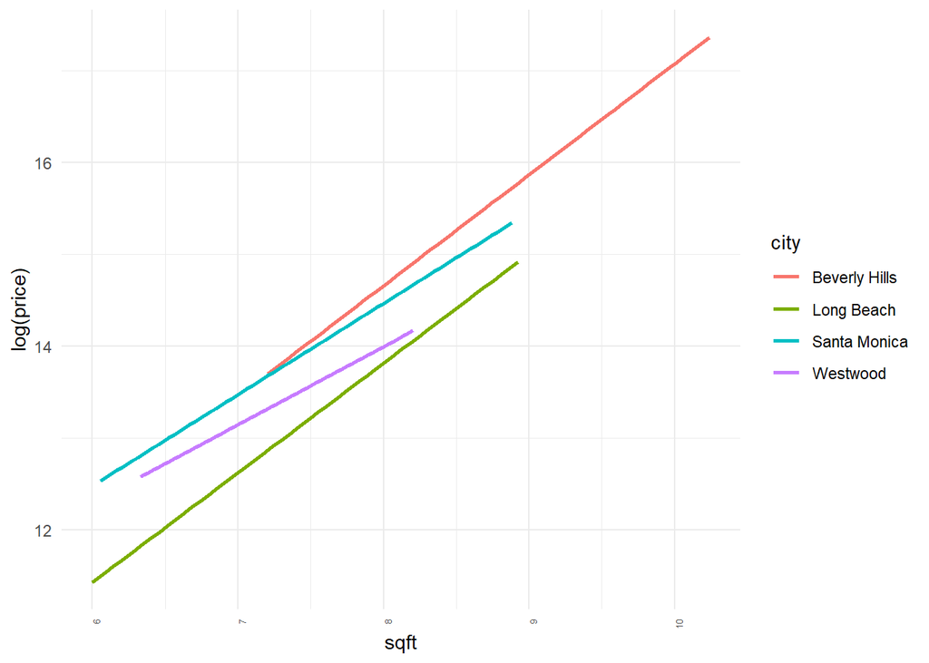

```r
# Plot of interaction
ggplot(LA_clean, aes(log(sqft), log(price)))+
  theme_minimal() +
  geom_smooth(method = "lm", se = F, aes(col = city)) +
  theme(axis.text.x = element_text(angle = 90, hjust = 1, size = 5)) +
  labs("price ~ sqft * city", x = "sqft")
```

This interaction model is a tricky model to interpret. Here is some guidance:

1. Beverly Hills is the (missing) reference city in the model, assuming you have allowed the `lm()` function assign factor levels alphabetically.
2. There are three sorts of coefficients reported in the regression output for an interaction model:
- The **intercept** is the average value of the target when the inputs are 0 (for numeric variables) or the reference category (for categorical variables). Since there are two predictors in this model, sqft and city, the intercept will be average log price when log sqft is 0 and city is Beverly Hills. Log sqft will never be 0 so the intercept in this model is not interpretable.
- The **main effects** are first four coefficients in the output. In the plot you created for this question you can see that there is a regression line for each city. Similarly in the model: there is no *single* relationship between log price and log sqft, and consequently the main effect for log sqft—which is the first reported coefficient in the model output—is conditional on city. Specifically, it denotes the relationship between log sqft and log price *in Beverly Hills*, the reference city. The main effects for a predictor in an interaction model will always be conditional on the levels of the variable with which it has been interacted.
- The **interaction effects** are the final 3 coefficients in the output. (The colon indicates the interaction, as in “log(sqft):cityLong Beach.”). These coefficients estimate the *change in the slope of the regression line* for each city *compared to Beverly Hills*. If the interaction coefficients are negative that means that the regression line relating log sqft to log price is less steep for that particular city in comparison to Beverly Hills, or, equivalently, that the relationship is less strong. Note that the coefficient for the first interaction term, log(sqft):cityLong Beach, is (very slightly) negative but not statistically significant. What does this mean? The slope of the regression line in LB is statistically indistinguishable from the one in BH.

## Q5

What should Andrew say in his presentation? Write a brief summary of the quantitative evidence that he should use to support this recommendation.

> Answer: We have identified a strong positive relationship between price and square footage indicated by our visuals. Our R-squared statistic, which helps identify strong relationships, is high at .77. This statistic is found after we log transform the model logrithmically raising it from .72 to .77. This is also supported by similar RMSE’s at 1857904 and 1788187 for a log transformed RMSE. As we look at the difference in slope between cities, which helps us indicate overall effect, we see that Beverley Hills has the steepest slope and therefore increases in price at a higher rate for additional square footage than the other cities. The recommendation would be to prioritize BH for home updates. Followed by BH, Long Beach increases the second most for each square foot added at about 1.5% less. This is supported visually in our graphical representation.

## Challenge

Are these differences between cities practically significant (as opposed to just statistically significant)? To answer this question it is helpful to translate city differences into concrete dollar terms. Use the information from the regression to calculate the price returns associated with increasing the size of (pick your numbers) a 3000 square foot SFR worth 500k by 20% or 40% or…? Additionally, use the SE in the regression output to incorporate uncertainty into your answer, in order to report a range rather than a single summary dollar amount.